# Project Practical Machine Learning: Human Activity Recognition

Dr. Gerhard Hellstern

```r
library(AppliedPredictiveModeling)
library(caret)
```

```r
library("rpart.plot")
```

### Loading the data and first cleaning

```r
alldata <- read.csv("pml-training.csv")
evaldata<- read.csv("pml-testing.csv")
#View(alldata)
colnames(alldata)
```

```
##   [1] "X"                        "user_name"
##   [3] "raw_timestamp_part_1"     "raw_timestamp_part_2"
##   [5] "cvtd_timestamp"           "new_window"
##   [7] "num_window"               "roll_belt"
##   [9] "pitch_belt"               "yaw_belt"
##  [11] "total_accel_belt"         "kurtosis_roll_belt"
##  [13] "kurtosis_picth_belt"      "kurtosis_yaw_belt"
##  [15] "skewness_roll_belt"       "skewness_roll_belt.1"
##  [17] "skewness_yaw_belt"        "max_roll_belt"
##  [19] "max_picth_belt"           "max_yaw_belt"
##  [21] "min_roll_belt"            "min_pitch_belt"
##  [23] "min_yaw_belt"             "amplitude_roll_belt"
##  [25] "amplitude_pitch_belt"     "amplitude_yaw_belt"
##  [27] "var_total_accel_belt"     "avg_roll_belt"
##  [29] "stddev_roll_belt"         "var_roll_belt"
```

[output cut: 65 more lines]

```r
summary(alldata$classe)
```

```
##    A    B    C    D    E
## 5580 3797 3422 3216 3607
```

```r
#summary(evaldata)
```

By explorative data analysis of the training set the following characteristic ist remarkable: There are a significant number of variables which are missing (empty or NA) or not valid #DIV/0!. Basiscally they contain only sensible information, when the variable “new_window==Yes”.

It is further remarkable that these variable are all empty in the “pml-testing” dataset. For theses reasons I decided to eliminate these variables to reduce the complexity. Furthermore - as usual - out of “pml-training” a training and a testing set are created to estimate the out-of-sample-error.

## Preparing the data

```r
alldata<-subset(alldata,alldata$new_window=="no")

set.seed(3433)
testIndex = createDataPartition(alldata$classe, p = 0.75,list=FALSE)
training = alldata[testIndex,]
testing =  alldata[-testIndex,]

training<-subset(training,select=c(classe,user_name,raw_timestamp_part_1,raw_timestamp_part_2,cvtd_timestamp,num_window,roll_belt,pitch_belt,yaw_belt,total_accel_belt,gyros_belt_x,gyros_belt_y,gyros_belt_z,accel_belt_x,accel_belt_y,accel_belt_z,magnet_belt_x,magnet_belt_y,magnet_belt_z,roll_arm,pitch_arm,yaw_arm,total_accel_arm,gyros_arm_x,gyros_arm_y,gyros_arm_z,accel_arm_x,accel_arm_y,accel_arm_z,magnet_arm_x,magnet_arm_y,magnet_arm_z,roll_dumbbell,pitch_dumbbell,yaw_dumbbell,total_accel_dumbbell,gyros_dumbbell_x    ,gyros_dumbbell_y,gyros_dumbbell_z,accel_dumbbell_x,accel_dumbbell_y,accel_dumbbell_z,magnet_dumbbell_x,magnet_dumbbell_y,magnet_dumbbell_z,roll_forearm,pitch_forearm,yaw_forearm,total_accel_forearm,gyros_forearm_x,gyros_forearm_y,gyros_forearm_z,accel_forearm_x,accel_forearm_y,accel_forearm_z,magnet_forearm_x,magnet_forearm_y,magnet_forearm_z))


testing<-subset(testing,select=c(classe,user_name,raw_timestamp_part_1,raw_timestamp_part_2,cvtd_timestamp,num_window,roll_belt,pitch_belt,yaw_belt,total_accel_belt,gyros_belt_x,gyros_belt_y,gyros_belt_z,accel_belt_x,accel_belt_y,accel_belt_z,magnet_belt_x,magnet_belt_y,magnet_belt_z,roll_arm,pitch_arm,yaw_arm,total_accel_arm,gyros_arm_x,gyros_arm_y,gyros_arm_z,accel_arm_x,accel_arm_y,accel_arm_z,magnet_arm_x,magnet_arm_y,magnet_arm_z,roll_dumbbell,pitch_dumbbell,yaw_dumbbell,total_accel_dumbbell,gyros_dumbbell_x,gyros_dumbbell_y,gyros_dumbbell_z,accel_dumbbell_x,accel_dumbbell_y,accel_dumbbell_z,magnet_dumbbell_x,magnet_dumbbell_y,magnet_dumbbell_z,roll_forearm,pitch_forearm,yaw_forearm,total_accel_forearm,gyros_forearm_x,gyros_forearm_y,gyros_forearm_z,accel_forearm_x,accel_forearm_y,accel_forearm_z,magnet_forearm_x,magnet_forearm_y,magnet_forearm_z))

evaldata<-subset(evaldata,select=c(user_name,raw_timestamp_part_1,raw_timestamp_part_2,cvtd_timestamp,num_window,roll_belt,pitch_belt,yaw_belt,total_accel_belt,gyros_belt_x,gyros_belt_y,gyros_belt_z,accel_belt_x,accel_belt_y,accel_belt_z,magnet_belt_x,magnet_belt_y,magnet_belt_z,roll_arm,pitch_arm,yaw_arm,total_accel_arm,gyros_arm_x,gyros_arm_y,gyros_arm_z,accel_arm_x,accel_arm_y,accel_arm_z,magnet_arm_x,magnet_arm_y,magnet_arm_z,roll_dumbbell,pitch_dumbbell,yaw_dumbbell,total_accel_dumbbell,gyros_dumbbell_x,gyros_dumbbell_y,gyros_dumbbell_z,accel_dumbbell_x,accel_dumbbell_y,accel_dumbbell_z,magnet_dumbbell_x,magnet_dumbbell_y,magnet_dumbbell_z,roll_forearm,pitch_forearm,yaw_forearm,total_accel_forearm,gyros_forearm_x,gyros_forearm_y,gyros_forearm_z,accel_forearm_x,accel_forearm_y,accel_forearm_z,magnet_forearm_x,magnet_forearm_y,magnet_forearm_z))
```

The structure of the problem, i.e. predict one out of five classes suggests to use a tree model setup for prediction. Logistic or even linear regression seems not to be optimal.

So to get a feeling of the “difficulty” of the problem, just apply the simple CART-technique:

## CART Algo

```r
modelCart<-train(classe~.,method="rpart",data=training,trControl = trainControl(method = "cv"))
print(modelCart$finalModel)
```

```
## n= 14414
##
## node), split, n, loss, yval, (yprob)
##       * denotes terminal node
##
##    1) root 14414 10310 A (0.28 0.19 0.17 0.16 0.18)
##      2) roll_belt< 130.5 13216  9121 A (0.31 0.21 0.19 0.18 0.11)
##        4) pitch_forearm< -33.95 1163     7 A (0.99 0.006 0 0 0) *
##        5) pitch_forearm>=-33.95 12053  9114 A (0.24 0.23 0.21 0.2 0.12)
##         10) cvtd_timestamp02/12/2011 13:33>=0.5 967   243 A (0.75 0.25 0 0 0) *
##         11) cvtd_timestamp02/12/2011 13:33< 0.5 11086  8547 B (0.2 0.23 0.23 0.21 0.13)
##           22) magnet_dumbbell_z< -93.5 1413   568 A (0.6 0.27 0.047 0.058 0.022) *
##           23) magnet_dumbbell_z>=-93.5 9673  7226 C (0.14 0.22 0.25 0.24 0.15)
##             46) raw_timestamp_part_1< 1.32249e+09 387     0 A (1 0 0 0 0) *
##             47) raw_timestamp_part_1>=1.32249e+09 9286  6839 C (0.11 0.23 0.26 0.25 0.15)
##               94) raw_timestamp_part_1< 1.32249e+09 470     9 B (0.015 0.98 0.0043 0 0) *
##               95) raw_timestamp_part_1>=1.32249e+09 8816  6371 C (0.11 0.19 0.28 0.26 0.16)
##                190) roll_dumbbell< -61.80313 1249   374 C (0.015 0.11 0.7 0.05 0.12) *
##                191) roll_dumbbell>=-61.80313 7567  5350 D (0.13 0.2 0.21 0.29 0.17)
##                  382) cvtd_timestamp02/12/2011 14:57>=0.5 347     0 B (0 1 0 0 0) *
##                  383) cvtd_timestamp02/12/2011 14:57< 0.5 7220  5003 D (0.13 0.17 0.22 0.31 0.18)
##                    766) cvtd_timestamp05/12/2011 11:24>=0.5 672   268 B (0.36 0.6 0.043 0 0) *
##                    767) cvtd_timestamp05/12/2011 11:24< 0.5 6548  4331 D (0.11 0.12 0.24 0.34 0.19)
##                     1534) cvtd_timestamp30/11/2011 17:11>=0.5 1002   545 C (0.2 0.35 0.46 0 0) *
##                     1535) cvtd_timestamp30/11/2011 17:11< 0.5 5546  3329 D (0.094 0.082 0.2 0.4 0.23) *
##      3) roll_belt>=130.5 1198     9 E (0.0075 0 0 0 0.99) *
```

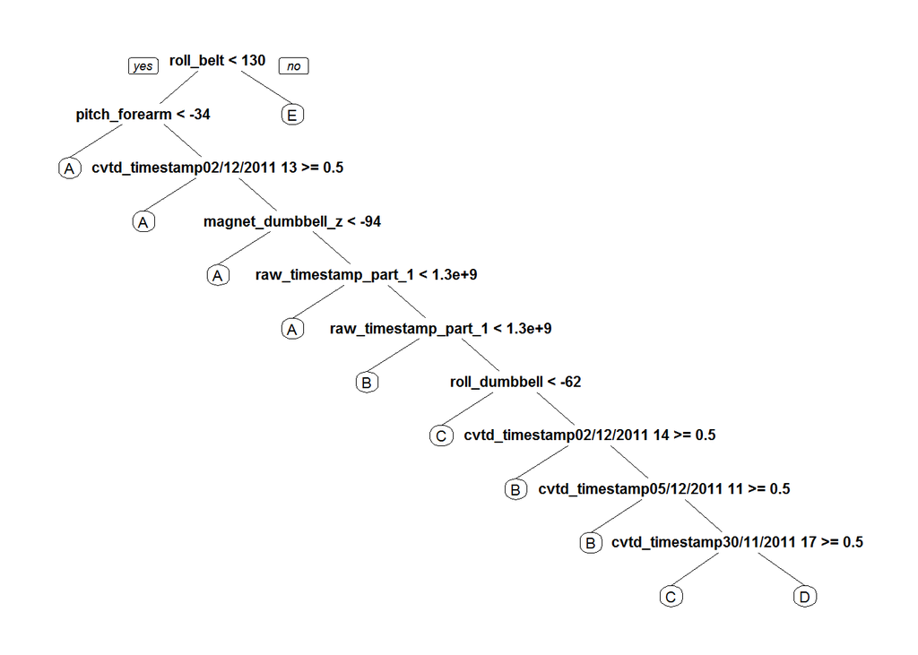

```r
prp(modelCart$finalModel)
```

```r
pred1<-predict(modelCart,newdata=testing,type="raw")
CM_Cart<-confusionMatrix(pred1,testing$classe)
CM_Cart
```

```
## Confusion Matrix and Statistics
##
##           Reference
## Prediction    A    B    C    D    E
##          A 1004  219   20   23   12
##          B   93  369    9    0    0
##          C   85  182  443   22   41
##          D  181  159  366  741  429
##          E    4    0    0    0  400
##
## Overall Statistics
##
##                Accuracy : 0.6158
##                  95% CI : (0.6019, 0.6296)
##     No Information Rate : 0.2847
##     P-Value [Acc > NIR] : < 2.2e-16
##
##                   Kappa : 0.5184
##  Mcnemar's Test P-Value : NA
##
## Statistics by Class:
##
##                      Class: A Class: B Class: C Class: D Class: E
## Sensitivity            0.7345  0.39720  0.52864   0.9427  0.45351
## Specificity            0.9202  0.97366  0.91675   0.7174  0.99898
## Pos Pred Value         0.7856  0.78344  0.57309   0.3950  0.99010
## Neg Pred Value         0.8970  0.87070  0.90196   0.9846  0.89040
## Prevalence             0.2847  0.19346  0.17451   0.1637  0.18367
## Detection Rate         0.2091  0.07684  0.09225   0.1543  0.08330
## Detection Prevalence   0.2661  0.09808  0.16097   0.3907  0.08413
## Balanced Accuracy      0.8273  0.68543  0.72270   0.8301  0.72625
```

As can be seen in the confusion matrix, the prediction quality out-of-sample, as measured e.g. with the accuracy is not overwhelming, but is also not too disappointing.

```r
model_rf<-train(classe~.,method="rf",data=training,trControl = trainControl(method = "cv"))
print(model_rf$finalModel)
```

```
##
## Call:
##  randomForest(x = x, y = y, mtry = param$mtry)
##                Type of random forest: classification
##                      Number of trees: 500
## No. of variables tried at each split: 40
##
##         OOB estimate of  error rate: 0.05%
## Confusion matrix:
##      A    B    C    D    E  class.error
## A 4104    0    0    0    0 0.0000000000
## B    1 2787    1    0    0 0.0007171029
## C    0    3 2511    0    0 0.0011933174
## D    0    0    2 2359    0 0.0008470987
## E    0    0    0    0 2646 0.0000000000
```

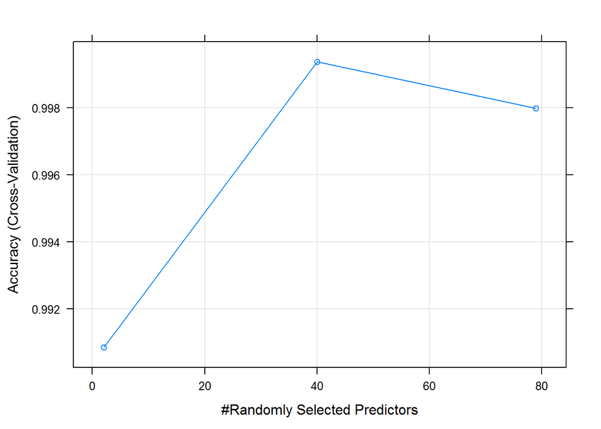

```r
plot(model_rf)
```

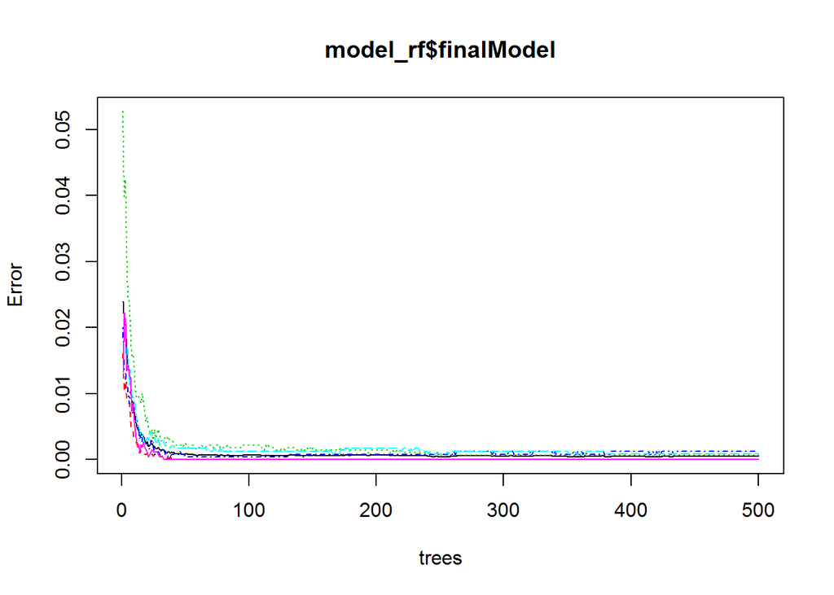

```r
plot(model_rf$finalModel)
```

```r
##In-sample estimation
pred_rf<-predict(model_rf,newdata=training,type="raw")
CM_RF0<-confusionMatrix(pred_rf,training$classe)
CM_RF0
```

```
## Confusion Matrix and Statistics
##
##           Reference
## Prediction    A    B    C    D    E
##          A 4104    0    0    0    0
##          B    0 2789    0    0    0
##          C    0    0 2514    0    0
##          D    0    0    0 2361    0
##          E    0    0    0    0 2646
##
## Overall Statistics
##
##                Accuracy : 1
##                  95% CI : (0.9997, 1)
##     No Information Rate : 0.2847
##     P-Value [Acc > NIR] : < 2.2e-16
##
##                   Kappa : 1
##  Mcnemar's Test P-Value : NA
##
## Statistics by Class:
##
##                      Class: A Class: B Class: C Class: D Class: E
## Sensitivity            1.0000   1.0000   1.0000   1.0000   1.0000
## Specificity            1.0000   1.0000   1.0000   1.0000   1.0000
## Pos Pred Value         1.0000   1.0000   1.0000   1.0000   1.0000
## Neg Pred Value         1.0000   1.0000   1.0000   1.0000   1.0000
## Prevalence             0.2847   0.1935   0.1744   0.1638   0.1836
## Detection Rate         0.2847   0.1935   0.1744   0.1638   0.1836
## Detection Prevalence   0.2847   0.1935   0.1744   0.1638   0.1836
## Balanced Accuracy      1.0000   1.0000   1.0000   1.0000   1.0000
```

```r
##Out-of sample estimation
pred_rf<-predict(model_rf,newdata=testing,type="raw")
CM_RF<-confusionMatrix(pred_rf,testing$classe)
CM_RF
```

```
## Confusion Matrix and Statistics
##
##           Reference
## Prediction    A    B    C    D    E
##          A 1367    1    0    0    0
##          B    0  928    0    0    0
##          C    0    0  838    1    0
##          D    0    0    0  784    0
##          E    0    0    0    1  882
##
## Overall Statistics
##
##                Accuracy : 0.9994
##                  95% CI : (0.9982, 0.9999)
##     No Information Rate : 0.2847
##     P-Value [Acc > NIR] : < 2.2e-16
##
##                   Kappa : 0.9992
##  Mcnemar's Test P-Value : NA
##
## Statistics by Class:
##
##                      Class: A Class: B Class: C Class: D Class: E
## Sensitivity            1.0000   0.9989   1.0000   0.9975   1.0000
## Specificity            0.9997   1.0000   0.9997   1.0000   0.9997
## Pos Pred Value         0.9993   1.0000   0.9988   1.0000   0.9989
## Neg Pred Value         1.0000   0.9997   1.0000   0.9995   1.0000
## Prevalence             0.2847   0.1935   0.1745   0.1637   0.1837
## Detection Rate         0.2847   0.1933   0.1745   0.1633   0.1837
## Detection Prevalence   0.2849   0.1933   0.1747   0.1633   0.1839
## Balanced Accuracy      0.9999   0.9995   0.9999   0.9987   0.9999
```

Both, the in-sample and the out-of-sample accuracy are remarkable good, so this model can be used for prediction of the evaluation data.

## Preparing the output of the evaluation data:

```r
model_final<-model_rf
pred_final<-predict(model_final,newdata=evaldata,type="raw")
pred_final
```

```
##  [1] B A B A A E D B A A B C B A E E A B B B
## Levels: A B C D E
```

```r
pml_write_files = function(x){
  n = length(x)
  for(i in 1:n){
    filename = paste0("problem_id_",i,".txt")
    write.table(x[i],file=filename,quote=FALSE,row.names=FALSE,col.names=FALSE)
  }
}

pml_write_files(pred_final)
```

Note: All 20 test cases of the evaluation data are predicted correctly !!